# Final Exam

Jiaming Chen

12/9/2017

# 1. (20 pts) Explain the Bias/Variance trade-off.

The big picture or general goal of machine/statistical learning is to approximate the target function $f(x)=y$ which generate the observations. Also we want to estimate how close is the approximation we made $\hat{f}(x)$ to the ground truth $y$. Therefore the best approach to achieve this goal with the data we have in hand is to devide them into two subset: training set and test set. We use training set of approximate $f(x)$ and use the test set to evaluate how well the approximation $\hat{f}(x)$ will perform if unseen samples, which are not included in the training set, are presented. We can estimate the error that $\hat{f}(x)$ will make with $E[(y-\hat{f}(x))^2]$. To decompose this term, we have:

$E[(y-\hat{f}(x))^2] = E[(y-E[\hat{f}(x)]+E[\hat{f}(x)] - \hat{f}(x))^2]=\\E[(y-E[\hat{f}(x)])^2] + E[(E[\hat{f}(x)] - \hat{f}(x))^2] + E[2(y-E[\hat{f}(x)])(E[\hat{f}(x)] - \hat{f}(x))] = \\ E[(y-E[\hat{f}(x)])^2] + E[(E[\hat{f}(x)] - \hat{f}(x))^2] + 2(y - E[\hat{f}(x)])(E[\hat{f}(x)] - E[\hat{f}(x)])=\\ (E[y]-E[\hat{f}(x)])^2 + Var(\hat{f}(x))=\\Var(\hat{f}(x)) + [Bias(\hat{f}(x))]^2 + Var(\epsilon)$

$[Bias(\hat{f}(x))]^2$ refers to the “distance” between the target function and the our pool of candidate models. If the flexibility of model is high, the number of possible models is high. If the target function is indeed one of the possible models, then this term would be zero.

It’s like that we are trying to find a ball with which we can win lottery in a pool we select. Each ball stands for a possible $f$. When the pool we’re searching in is very big and the ball is indeed in that pool, then it’s actually possible that we catch that ball we want. However in real life, the target function may be extreme complex and the target function is usually not in the pool.

$Var(\hat{f}(x))$ measures the amount that $\hat{f}$ would change if trained by a different data set. In the other words, it measures the “size” of the pool.

If the real life problem is too complex and we can not have the first prise lottery ball (target function)in our pool anyway, then we wish to have something close to it (like a second prise lottery ball?). By increasing the size of the pool (flexibility), we may have a chance to get something good (close to target function) into our pool. But when we take one ball out from that big pool, we may also end up with something extremely bad (overfitting). Using a small pool means that it’s unlikely that we get the something very good or very bad (low variance).

# 2. (20 pts) Explain the Flexibility / Interpretability trade-off.

When we choose an algorithm to train a model to fit our data, there are two criterias to deicide which algorithm to choose in our case. The first criteria is the ability that the model trained by the algorithm predicts unseen data. For example, Support Vector Machine performs very good in a large range of applications because it can fit both linear and nonlinear data. While linear regression performs well only for certain cases where the relationship between predictors and response is linear. So the flexibility of SVM is higher compared to linear regression.

The other criteria is interpretability, which measures the amount of information that we can refer from the model. Lasso is a model with high interpretability, we can actually refer the importance of each predictor using Lasso. However Lasso assumes a linear relationship between predictors and response and it’s very restrictive in estimating he coefficients, which limits its application range. Another example is Neural Network, it has few assumptions and can fit linear, nonlinear, low dimensional, high dimensional data. It’s very flexible. However the behaviour of neurons is not interpretable, we can not refer any information about the data from Neural Network. It’s like a blackbox, we know the input and output but we can not see what’s the operation within that blackbox.

In some applications, we may prefer more interpretable model because we can draw some conclusions by analyzing the data. ANOVA, AB test, Lasso etc. they’re often used by business analyst and data analyst. In some other case, we don’t care about how the model really works, all we need is precise prediction. Applications like machine learning, AI prefers this type of models.

# 3.

## a)

It’s a regression problem. First we want to know the impact of each factor in this experiment, it means that we need to apply a more interpretable model here. Second, the total number of observations is very limited (only 32 plots), so if we use too flexible model, we may face the problem of overfitting. Also, we want to know the trend with which the response will change if increase CO$_2$ and/or temperature. In this case, I would use GAM model. GAM model gives the result of T test for every predictors and we can thus infer the relevance and impact of each predictor. We’re not sure if the relationship between predictors and response is linear or not, so I am not sure about the result by using Lasso regression.

## b)

It’s a classification problem. And the sample size is big enough for us to train a complex model or flexible model. In the question, we don’t really care about the impact of each predictor. As long as the predictions we make are accurate, the model is good enough. So I may use SVM in this case, SVM is suitable for classification and flexible enough if the data in nonlinear, plus we have enough data to train SVM without worrying too much about overfitting.

## c)

It’s a regression problem. Since the covariates may have non-linear effect on the response, Lasso and Ridge regressions are excluded. The best choice here is to use GAM model, it only assumes piecewise linearity and is able to fit a nonlinear curve by smoothing splines. Plus the T-test result for each covairate can tell us about the importance of covariates as well. The fitting curve can finally be used to maximize the product strength.

# 4. My personalized dataset. Wow~!

````
```r
# Assuming you've downloaded StudentDataSets.Rdata into the same
# directory as your Rmarkdown file...
load('StudentDataSets.Rdata')
# now there should be datasets Adjie, AdobaOtchey, ... in your workspace.
```
````

```r
rm(list=setdiff(ls(), "Chen"))
```

## Explore the data

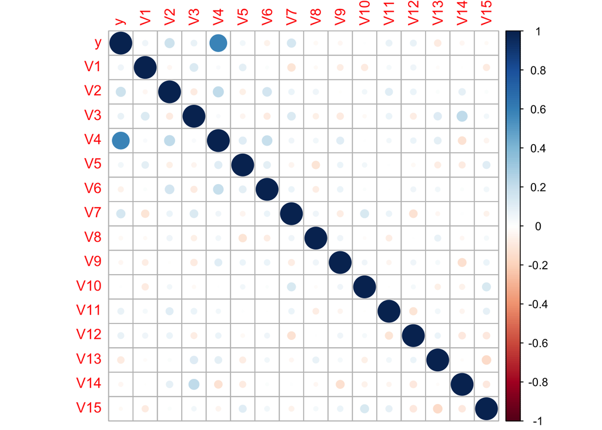

```r
library(corrplot)
library(GGally) # pairs plot
corrM <- cor(Chen, method = "pearson", use = "complete.obs")
corrplot(corrM, method="circle")
```

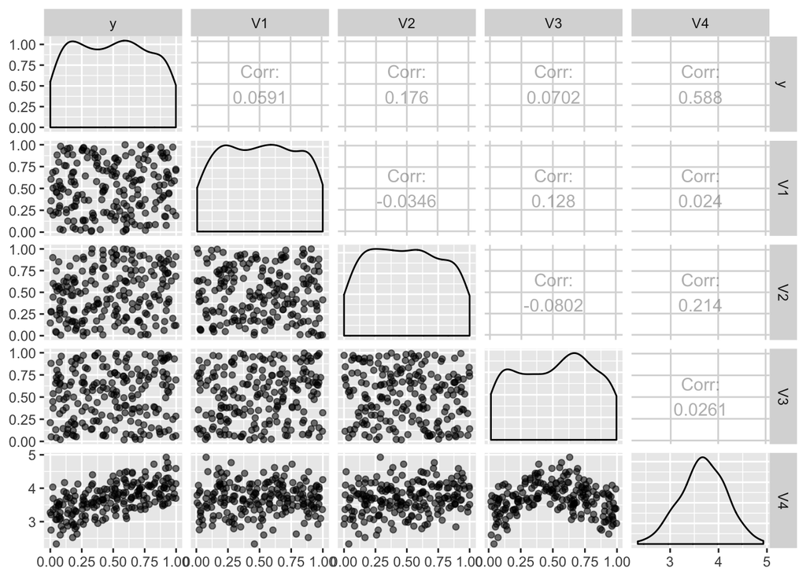

```r
ggpairs(Chen,columns = 1:5, aes(alpha = 0.5))
```

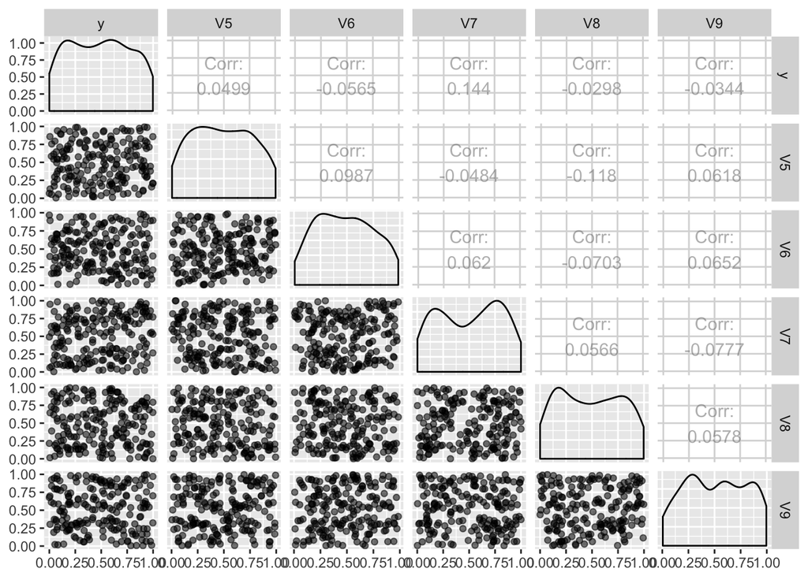

```r
ggpairs(Chen,columns = c(1,6:10), aes(alpha = 0.5))
```

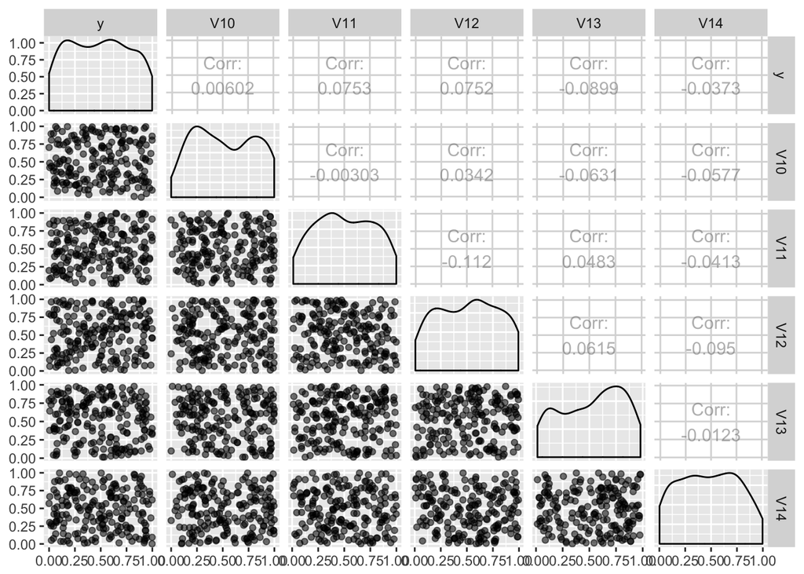

```r
ggpairs(Chen,columns = c(1,11:15), aes(alpha = 0.5))
```

In the following code, we’re going to check > bagged tree > Random Forest with p/2 features > Random Forest with sqrt(p) features > Boosted Tree > Ridge Regression > Lasso Regression > lasso OneSE > SVM with linear kernel (cost = 5) > SVM with radial kernel (cost = 5) > GAM (no predictor smoothed) > KNN with optimized K

Load the package for every learning algorithm, set up the tuning grid.

```r
library(caret)  # for the train() function
library(tree)
library(rpart)
library(rpart.plot)
library(randomForest)
library(gbm) # generalized boost models
library(e1071)        # for svm() function
library(gam)   # gam
library(mgcv)
results <- NULL
p <- 15

# Repeated 4x5-fold Cross Validation
ctrl <- trainControl( method='repeatedcv', repeats=4, number=5)

# set the grid for lasso and ridge
grid_ridge <- data.frame(
  alpha  = 0,  # 0 => Ridge Regression
  lambda = exp(seq(-5, 8, length=100)) )
grid_lasso <- data.frame(
  alpha  = 1,  # 1 => LASSO
  lambda = exp(seq(-8, 2, length=100)) )

#formula for GAM
f <- paste(names(Chen)[1], "~", paste(names(Chen)[-1], collapse="+"))
```

*When using prune.tree method I get the error of “singlenode tree”. And when I check the splits of pruned.tree, it’s actually a vector which contains two empty strings. This also reflects that the simple tree model is very unstable, the structure of the tree highly depends on the split of training and test set. Sometimes the tree collapse to one single node and no meaningful prediction could be made from a single node tree. This is why I commented out the chunk of code for pruned.tree.*

```r
for( i in 1:100){
  temp  <- Chen
  test  <- temp %>% sample_frac(.5)
  train <- setdiff(temp, test)

  # # simple tree
  # my.tree <- tree( y ~ ., data=train)
  # cv.tree <- cv.tree( my.tree, FUN=prune.tree, K=10)
  # num.leaves <- cv.tree$size[which.min(cv.tree$dev)]
  # pruned.tree <- prune.tree( my.tree, best=num.leaves, method='deviance' )
  # #yhat <- predict(pruned.tree, newdata=test)
  # results <- tryCatch({
  #   yhat <- predict(pruned.tree, newdata=test)
  #   rbind(results, data.frame(RMSE=mean( (yhat - test$y)^2 ),
  #                                      type='CV-Prune'))
  # }, warning = function(war) {
  #   return('CV-Prune')
  # }
  #
  # )

  # bagged tree
  bagged <- randomForest( y ~ ., data=train, mtry=p)

  yhat   <- predict(bagged, newdata=test)
  results <- rbind(results, data.frame(RMSE=mean( (yhat - test$y)^2 ),
                                       type='Bagged'))


  # random forest
  RF     <- randomForest( y ~ ., data=train, mtry=p/2)
  # yhat   <- predict(RF, newdata=test, type='class')
  # results <- rbind(results, data.frame(RMSE=mean( (yhat - test$y)^2 ),
  #                                      type='RF - p/2'))

  yhat   <- predict(RF, newdata=test, type='class')
  results <- rbind(results, data.frame(RMSE=mean( (yhat - test$y)^2 ),
                                       type='RF - p/2'))


  # random forest
  RF     <- randomForest( y ~ ., data=train, mtry=sqrt(p))
  yhat   <- predict(RF, newdata=test)
  results <- rbind(results, data.frame(RMSE=mean( (yhat - test$y)^2 ),
                                       type='RF - sqrt(p)'))

  # boosted tree
  boost <- gbm(y ~ .,
    data=train,
    distribution = 'gaussian',  # use gaussian for regression trees
    interaction.depth = 2,  n.trees = 2000, shrinkage=.01 )
  yhat <- predict(boost, newdata=test, n.trees=2000, type='response')
  results <- rbind(results, data.frame(RMSE=mean( (yhat - test$y)^2 ),
                                       type='Boosting'))

  # ridge regression
  ridge <- train( y ~ ., data=train, method='glmnet', trControl = ctrl,
                tuneGrid=grid_ridge,
                lambda= grid_ridge$lambda )
  yhat   <- predict(ridge, newdata=test)
  results <- rbind(results, data.frame(RMSE=mean( (yhat - test$y)^2 ),
                                       type='ridge'))

  # lasso regression
  lasso <- train( y ~ ., data=train, method='glmnet', trControl = ctrl,
                tuneGrid=grid_lasso,
                lambda= grid_lasso$lambda )
  yhat   <- predict(lasso, newdata=test)
  results <- rbind(results, data.frame(RMSE=mean( (yhat - test$y)^2 ),
                                       type='lasso'))

  # lasso OneSE
  bestTuneOneSE <- lasso$results %>%
    mutate( index = 1:n() ) %>%
    filter( RMSE <= min( RMSE + RMSESD/sqrt(20) ) ) %>%
    arrange(desc(lambda)) %>%
    slice(1)
  tuneGrid <- bestTuneOneSE %>% dplyr::select(alpha, lambda) %>% as.data.frame()
  lasso_1SE <- train( y ~ ., data=train, method='glmnet',
                trControl=ctrl, tuneGrid=tuneGrid,
                lambda= tuneGrid$lambda )
  yhat   <- predict(lasso_1SE, newdata=test)
  results <- rbind(results, data.frame(RMSE=mean( (yhat - test$y)^2 ),
                                       type='lasso_1SE'))



  # SVM linear kernal

  # cost 5
  Svm_linear <- svm( y ~ .,      # Which covarites?
                data=train,          # where is the data I'm using
                kernel='linear',    # What kernel are we using
                cost=5,            # How large a penalty for violations
                scale=TRUE)         # Scale the covariates first; Default is TRUE
  yhat   <- predict(Svm_linear, newdata=test)
  results <- rbind(results, data.frame(RMSE=mean( (yhat - test$y)^2 ),
                                       type='Svm_linear'))

  # SVM radial kernal
  Svm_radial <- svm( y ~ ., data=train,
              kernel='radial', cost=5)
  yhat   <- predict(Svm_radial, newdata=test)
  results <- rbind(results, data.frame(RMSE=mean( (yhat - test$y)^2 ),
                                       type='Svm_radial'))

  # GAM
  GAM <- mgcv::gam(y ~ V1 + V2 + V3 + V4 + V5 + V6 + V7 + V8 + V9 + V10 + V11 + V12 + V13 + V14 + V15, data=train)
  yhat   <- predict(GAM, newdata=test)
  results <- rbind(results, data.frame(RMSE=mean( (yhat - test$y)^2 ),
                                       type='GAM'))

  # knn
  knn <- train(y ~ ., data=train,
               method='knn', tuneGrid=data.frame(k=c(5,7,9,12,15)))
  yhat   <- predict(knn, newdata=test)
  results <- rbind(results, data.frame(RMSE=mean( (yhat - test$y)^2 ),
                                       type='knn'))
}
```

[output not shown]

[output cut: 244 more lines]

[output not shown]

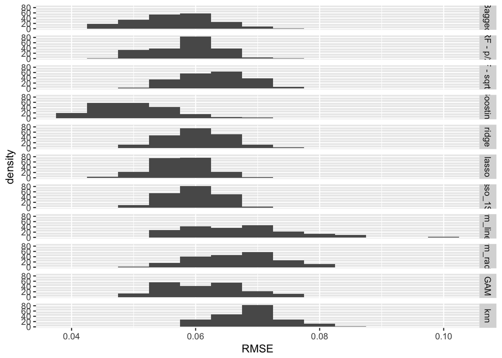

```r
ggplot(results, aes(x=RMSE, y=..density..)) +
     geom_histogram(binwidth=0.005) +
     facet_grid(type ~ .)
```

From this result we can see that Bootsting tree performs much better than other method. Boosting tree can give both accurate predictions and nice interpretation.

```r
results %>% group_by( type ) %>%
  summarise( mean.RMSE = mean(RMSE),
             sd.RMSE   = sd(RMSE))
```

```
## # A tibble: 11 x 3
##            type  mean.RMSE     sd.RMSE
##          <fctr>      <dbl>       <dbl>
##  1       Bagged 0.05693977 0.006379812
##  2     RF - p/2 0.05859527 0.005432140
##  3 RF - sqrt(p) 0.06291415 0.005436259
##  4     Boosting 0.04999538 0.006275372
##  5        ridge 0.06007874 0.005143409
##  6        lasso 0.05762256 0.004461292
##  7    lasso_1SE 0.05959314 0.004356725
##  8   Svm_linear 0.06706317 0.008730296
##  9   Svm_radial 0.06661235 0.006715519
## 10          GAM 0.06117343 0.006468730
## 11          knn 0.06894096 0.005422335
```

## Interpretability and Flexibility comment

In the following list, the flexibility is from high to low (generally)

### SVM

SVM has very high flexibility but low interpretability. We cannot know the importance of each predictor nor the relationship between predictors and response. For SVM, we can choose different kernels and different cost. I set the cost to 5 and tested linear kernal and radial kernel. The results of both are similar, variance of SVM performance is higher than other model with lower flexibility.

### KNN

KNN does not assume the linear relationship between predictors and response. It does not give an explicit form of the relationship between between predictors and response either. It can closely fit the model depending on the choice of K. So KNN is a low interpretability but high flexibility model. And because of the high dimensionality of this data, KNN turned out to perform poorly.

### Decision Trees

Bagged Tree and Boosting tree have the similar interpretability and flexibility. Random Forest has less interpretability but slightly higher flexibility than bagging and boosting. But in the result we can see that random forests do not have a better performance than bagging and boosting. Boosting has the best RMSE and it can also provide the relative importance for each predictors, which is very nice.

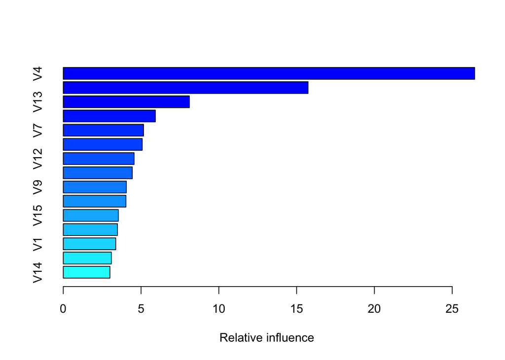

```
##     var   rel.inf
## V4   V4 26.447156
## V3   V3 15.734331
## V13 V13  8.105209
## V6   V6  5.920424
## V7   V7  5.159524
## V8   V8  5.074513
## V12 V12  4.551222
## V2   V2  4.437756
## V9   V9  4.053466
## V11 V11  4.030379
## V15 V15  3.537575
## V5   V5  3.482529
## V1   V1  3.373176
## V10 V10  3.093238
## V14 V14  2.999502
```

```r
summary(boost)
```

```r
importance(bagged)
```

```
##     IncNodePurity
## V1      0.2732699
## V2      0.3513258
## V3      1.1651731
## V4      3.1991721
## V5      0.2741659
## V6      0.3085875
## V7      0.3651459
## V8      0.3441079
## V9      0.2523995
## V10     0.1616216
## V11     0.2404100
## V12     0.2203879
## V13     0.4694383
## V14     0.2829434
## V15     0.2361538
```

### GAM

GAM has lower flexibility than trees but higher interpretability. Like the models discussed above, GAM can still be applied to data set where the relationship between predictor and response are nonlinear, but we need to specify which predicor to smooth. It’s an extension of linear regression, so the relationship between predictors and response is explicit. I didn’t use smooth spline here so I’m basiclly just doing linear regression…

```r
mgcv::summary.gam(GAM)
```

```
##
## Family: gaussian
## Link function: identity
##
## Formula:
## y ~ V1 + V2 + V3 + V4 + V5 + V6 + V7 + V8 + V9 + V10 + V11 +
##     V12 + V13 + V14 + V15
##
## Parametric coefficients:
##              Estimate Std. Error t value Pr(>|t|)
## (Intercept) -0.861575   0.238641  -3.610 0.000519 ***
## V1           0.098223   0.083894   1.171 0.244995
## V2           0.096644   0.094958   1.018 0.311719
## V3           0.062759   0.094041   0.667 0.506378
## V4           0.361272   0.053977   6.693  2.3e-09 ***
## V5           0.037352   0.087647   0.426 0.671077
## V6          -0.109528   0.091051  -1.203 0.232385
## V7           0.105373   0.090043   1.170 0.245210
## V8          -0.121082   0.082293  -1.471 0.144936
## V9          -0.016797   0.088038  -0.191 0.849147
## V10          0.003036   0.088437   0.034 0.972694
## V11         -0.008782   0.093624  -0.094 0.925491
## V12          0.042605   0.086878   0.490 0.625133
## V13         -0.243089   0.089684  -2.710 0.008144 **
## V14          0.097938   0.097088   1.009 0.315991
## V15         -0.029704   0.085664  -0.347 0.729645
## ---
## Signif. codes:  0 '***' 0.001 '**' 0.01 '*' 0.05 '.' 0.1 ' ' 1
##
##
## R-sq.(adj) =  0.345   Deviance explained = 44.4%
## GCV = 0.066061  Scale est. = 0.055491  n = 100
```

### ridge and lasso regression

Ridge and Lasso regression assume a linear relationship between predictors and response. The predictors which aren’t linear to response will be set to zero or very small number. We can infer the predictor importance from the result but the model is very inflexible that we need to check if our data has any nonlinear predictor or not. The prediction qualities of ridege and lasso regression are similar to GAM.

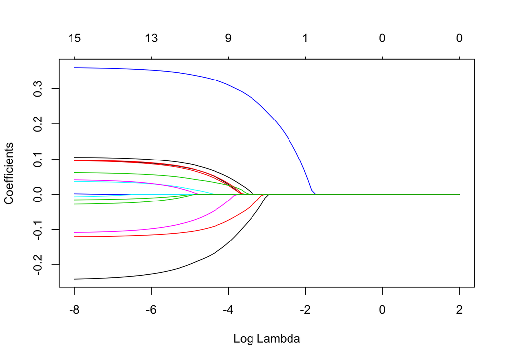

```r
plot.glmnet(lasso$finalModel, xvar='lambda')
```

```r
coef.glmnet( lasso$finalModel )
```

```
## 16 x 100 sparse Matrix of class "dgCMatrix"
```

```
##    [[ suppressing 100 column names 's0', 's1', 's2' ... ]]
```

[output not shown]

[output cut: 285 more lines]

```
## V1           0.096370975  0.096548868  0.096709669
## V2           0.094905362  0.095072392  0.095223375
## V3           0.061211811  0.061360403  0.061494727
## V4           0.359804808  0.359945762  0.360073174
## V5           0.036152617  0.036267886  0.036372081
## V6          -0.107689715 -0.107866345 -0.108026004
## V7           0.104578066  0.104654418  0.104723429
## V8          -0.120126447 -0.120218223 -0.120301180
## V9          -0.015542584 -0.015663130 -0.015772095
## V10          0.001195838  0.001372645  0.001532469
## V11         -0.006527258 -0.006743881 -0.006939692
## V12          0.040735861  0.040915403  0.041077697
## V13         -0.240174434 -0.240454421 -0.240707511
## V14          0.096564486  0.096696452  0.096815738
## V15         -0.027948444 -0.028117107 -0.028269568
```

## Summary

Let’s assume $y$ is the average Body Mass Index (BMI) of a country, $V1, V2, ... V15$ are the factors that influence the BMI (e.g. population density, time stamp, GDP, , latitude, etc.). We can infer the importance of each factor with Boosting, Bagging, Lasso and GAM. If given a new country and we want to estimate its average BMI, it may be a good idea to use Boosting tree because it gives the best RMSE as we see. However, if the timestamp turned out to be an relevant predictor and we want to predict the average BMI in the next ten years, we may want to use GAM to model it. GAM is based on linear model and we can extrapolate using the coefficients estimated. Sometimes we want to know how much will $y$ increase if $V$ increase by a certain unit, GAM is more suitable for this situation.

## Conclusion

There’re a bunch of models that we can use for this data. Also it may be a good idea to train KNN, SVM only using covariates selected by Lasso or Boosting. For this data, regression is challenging because of the irrelevant features not the nonlinearity. Thus using more flexible model, like SVM, KNN, GAM, won’t help much. Instead tree models work generally better, they’re more robust regarding irrelevant covariates.